# Construire un graphe interactif sous R

Sergio Ewane Ebouele

2018-11-15 22:33:56

# INTRODUCTION

La représentation graphique des données reste un moyen important d’explorer l’information contenue dans les jeux de données. Il est plus facile de construire un histogramme et de suspecter une distribution normale plutôt que de calculer des statistiques descriptives et d’avoir les mêmes suspissions.  
Dans ce tutoriel, nous voulons représenter les graphes (réseau) pour illustrer les liens qui peuvent exister entre des entités d’une communauté.

# DÉFINITION DE GRAPHES

D’après l’encyclopédie en ligne Wikipédia, La théorie des graphes est la discipline mathématique et informatique qui étudie les graphes.  
Un graphe est un modèle abstrait de dessins de réseaux reliant des objets. Ce modèle est constitué par la donnée de `points`, appelés nœuds ou sommets (en référence aux polyèdres), et de `liens` entre ces points. ces liens sont souvent symétriques (les graphes sont alors dits non orientés) et sont appelés des arêtes. L’image ci-dessous illutre la définition d’un graphe non orienté.

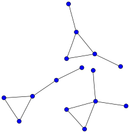

Ce tutoriel ne revient pas sur la théorie des graphes. Il illustre simplement la construction des graphes non orientés et interactif avec `R`.

# EXEMPLE PRATIQUE : REPRÉSENTATION DES LIENS ENTRE LES ÉTUDIANTS

Les données de ce papier sont fictives. Il s’agit d’un ensemble de $23$ étudiants d’une salle de classe qui participent aux activités parascolaire chaque fin de semaines. Sur la base de la participation aux activités, le papier représente graphiquement les liens significatifs qui existent entre les étudiants.

## La matrice de présence-absence (Mpa) aux activités parascolaires

|  | Etudiants | group | Cine | Soccer | Biblio | Club | Religion | Ferme | Resto |
| --- | --- | --- | --- | --- | --- | --- | --- | --- | --- |
| 1 | Bertholo | grp4 | 1 | 0 | 1 | 0 | 1 | 0 | 1 |
| 2 | Vanou | grp4 | 1 | 0 | 1 | 0 | 1 | 0 | 1 |
| 3 | Carmelito | grp4 | 0 | 1 | 1 | 1 | 0 | 0 | 0 |
| 4 | LeMaham | grp2 | 0 | 1 | 0 | 0 | 1 | 0 | 1 |
| 5 | Serge | grp2 | 1 | 1 | 0 | 0 | 0 | 1 | 1 |

## La structure de regroupement des étudiants

Les figures ci-dessous montrent qu’il existe une structure de cooccurrence entre les étudiants. La théorie de cette méthode est developpée dans le tutoriel des `null models`.

|  | temp | N0 | NODF | Cscore |
| --- | --- | --- | --- | --- |
| p.value | 0.622 | 0.916 | 0.842 | 0.022 |

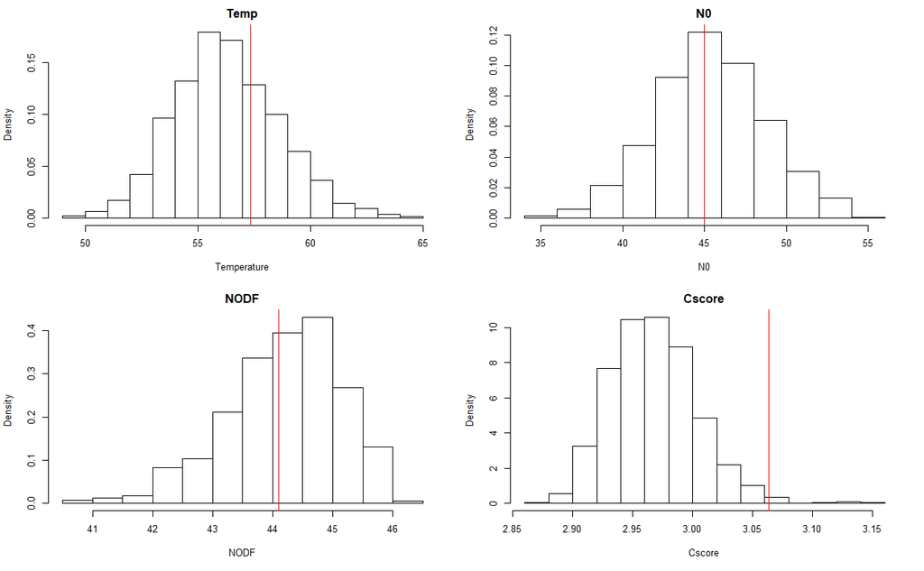

## La matrice de lien significatif entre les étudiants

Pour étudier la cooccurrence détectée ci-dessus en profondeur, le tutoriel mesure le lien entre les étudiants. Ce lien est mesuré par la distance de Sorensen. Cette diatance mesure la similarité ou la dissimilarité entre deux entités de la Mpa. Un lien est significatif lorsqu’il n’émane pas du hasard. Le tutoriel calcule la matrice de lien entre les étudiant et la représente grapgiquement.

|  | from | to | Sor | cooc | p.val.cooc | meanSimCooc | sens.cooc |
| --- | --- | --- | --- | --- | --- | --- | --- |
| 1 | Bertholo | Vanou | 1.0000000 | 4 | 0.046 | 2.282 | Similarite |
| 9 | Bertholo | Sorelite | 0.0000000 | 0 | 0.048 | 1.739 | Dissimilarite |
| 11 | Bertholo | LaHossou | 0.8888889 | 4 | 0.312 | 2.904 | Similarite |
| 18 | Bertholo | Roma | 0.2500000 | 1 | 0.228 | 2.331 | Dissimilarite |
| 30 | Vanou | Sorelite | 0.0000000 | 0 | 0.054 | 1.721 | Dissimilarite |

## Représentations graphiques

### Représentation du graphe non interactif

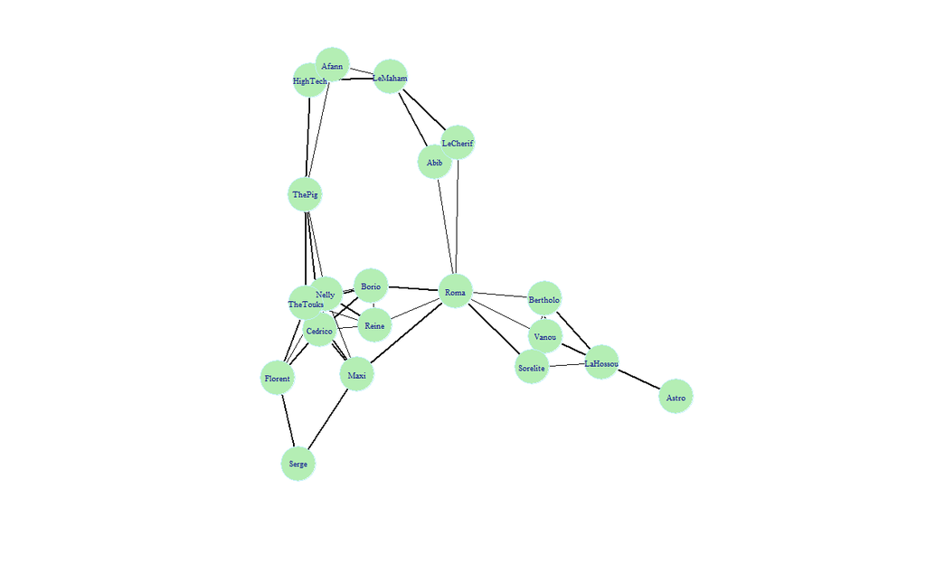

```r
# Définir les couleurs du graphe
color1<-"darkseagreen2" ; color2<-"lightblue1" ; color3<-"black"
# Jeu de données pour représenter le graphe
bdgraph<-Test.cooc[,c("from","to","Sor")]
g=graph.data.frame(bdgraph[,-3], directed=FALSE)
graph_layout=layout.fruchterman.reingold(g)
# Représentation du graphe
plot.igraph(g,
     layout=graph_layout,
     edge.width=(exp(bdgraph$Sor)),
     vertex.label.cex=0.7,
     vertex.color=color1,
     vertex.frame.color=color2,
     vertex.size=18,
     edge.color=color3
)
```

### Représentation du graphe interactif

```r
# Les noeuds du graphe
vertx<-as.factor(vertex.attributes(g)$name)  ;  nnod<-length(vertx)
netw3d.from<-as.character(Test.cooc$from)   ;  netw3d.to<-as.character(Test.cooc$to)
# Création du jeu de données de description des noeud
MyNodes<-data.frame( species=levels(vertx) )  ;  group<-c()
for (i in 1:nnod) {
  grp<-as.character(etudiants[as.character(etudiants$Etudiants)==as.character(MyNodes[i,]),2])
  group<-c(group,grp)
}
MyNodes<-data.frame( student=levels(vertx) , group=factor(group) , size=rep(5,nnod))
# Jeu de données qui spécifie les liens entre les étudiants
MyLinks<-data.frame(from=as.double(factor(netw3d.from,levels(vertx)))-1, # On fait -1 pour indexer à 0
                    to=as.double(factor(netw3d.to,levels(vertx)))-1,     # On fait -1 pour indexer à 0
                    Cooc=Test.cooc$cooc+1,                               # +1 pour eviter des liens nuls
                    typeLink=as.factor(Test.cooc$sens.cooc ))
# Vecteur de couleur des liens entre les étudiants
MyLinks$Linkcolor<-Colinks<-ifelse(MyLinks$typeLink=="Similarite","black","red")
# Les jeux de données pour représenter le graphe
head(MyNodes,3)
```

|  | student | group | size |
| --- | --- | --- | --- |
| 1 | Abib | grp1 | 5 |
| 2 | Afann | grp4 | 5 |
| 3 | Astro | grp4 | 5 |

```r
head(MyLinks,3)
```

|  | from | to | Cooc | typeLink | Linkcolor |
| --- | --- | --- | --- | --- | --- |
| 1 | 3 | 19 | 5 | Similarite | black |
| 2 | 3 | 16 | 1 | Dissimilarite | red |
| 3 | 3 | 8 | 5 | Similarite | black |

```r
# Représentation du graphe
forceNetwork(Links = MyLinks, Nodes = MyNodes, Source = "from", Target = "to", Value = "Cooc",
             NodeID = "student", Group = "group", opacity = 0.9, Nodesize = "size",
             linkDistance = 90, fontSize = 20, linkColour = Colinks, legend = TRUE)
```

[interactive chart not shown]